# Biological Databases & Datamining : Final

Creating a prediction model for diabetes patients.

Jakub Jurkovic mailto:jj3003@nyu.edu (NYU Abu Dhabi - Undergraduate)nyuad.nyu.edu  
2023-05-12

# Predicting Diabetes in patients

The following document is a final project fro Biological Databases & Data mining, in which we will attempt to build and evaluate multiple models to predict diabetes in patients. The caveat is that we expect our training data to contain a lot of missing data.

# Data Loading

Let’s Load the data and have a quick glance at it!

```r
data <- read.csv("PimaIndiansDiabetes.csv")
rmarkdown::paged_table(data)
```

| Pregnancies | Glucose | BloodPressure | SkinThickness | Insulin | BMI | DiabetesPedigreeFunction | Age | Outcome |
| --- | --- | --- | --- | --- | --- | --- | --- | --- |
| 6 | 148 | 72 | 35 | 0 | 33.6 | 0.627 | 50 | 1 |
| 1 | 85 | 66 | 29 | 0 | 26.6 | 0.351 | 31 | 0 |
| 8 | 183 | 64 | 0 | 0 | 23.3 | 0.672 | 32 | 1 |
| 1 | 89 | 66 | 23 | 94 | 28.1 | 0.167 | 21 | 0 |
| 0 | 137 | 40 | 35 | 168 | 43.1 | 2.288 | 33 | 1 |
| 5 | 116 | 74 | 0 | 0 | 25.6 | 0.201 | 30 | 0 |
| 3 | 78 | 50 | 32 | 88 | 31.0 | 0.248 | 26 | 1 |
| 10 | 115 | 0 | 0 | 0 | 35.3 | 0.134 | 29 | 0 |
| 2 | 197 | 70 | 45 | 543 | 30.5 | 0.158 | 53 | 1 |
| 8 | 125 | 96 | 0 | 0 | 0.0 | 0.232 | 54 | 1 |

[output cut: 658 more lines]

# Q1: Numerical & Categorical data

*Which variables are numeric and which are categorical?*

The attributes are:

- Pregnancies: Number of times pregnant
- Glucose: Plasma glucose concentration a 2 hours in an oral glucose tolerance test
- BloodPressure: Diastolic blood pressure (mm Hg)
- SkinThickness: Triceps skin fold thickness (mm)
- Insulin: 2-Hour serum insulin (mu U/ml)
- BMI: Body mass index (weight in kg/(height in m)^2)
- DiabetesPedigreeFunction: Diabetes pedigree function
- Age: Age (years)
- Outcome: Class variable (0 or 1) where 1 means they have diabetes.

From this we see that only **Outcome** is **categorical**. A debate can be held about pregnancies being categorical, however it is in the end just a discrete quantitative variable.

```r
# We see Outcome is categorical, hence will be recast as factor

#The code is commented out since corr plot complains with factors, will be factorized later
data$Outcome <- factor(data$Outcome, labels = c("Healthy", "Diabetes"))
```

# Q2: Overviewing the dataset

*Use appropriate graphs to predict which of the variables (on their own) are most helpful in predicting the outcome?* Let’s use Violin plots to overview our population, jitter dot plots to see clusterings and heat map to see associations.

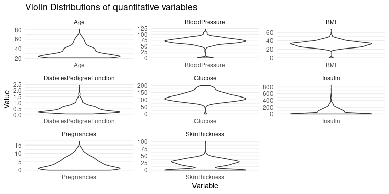

```r
data_long <-  read.csv("PimaIndiansDiabetes.csv") %>%
  pivot_longer(cols = 1:8, names_to = "Variable", values_to = "Value")

data_long %>% ggplot(mapping = aes(x=Variable, y=Value)) +
  geom_violin() +
  facet_wrap(vars(Variable), scales = "free") +
  labs(
    title = "Violin Distributions of quantitative variables",
    subtite = "Before Imputing"
  ) +
  theme_minimal()
```

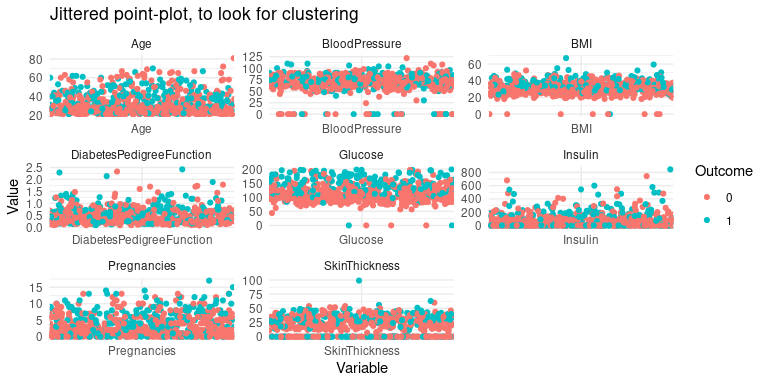

```r
data_long %>% ggplot(mapping = aes(x=Variable, y=Value, col=as.factor(Outcome))) +
  geom_jitter(width = 5) +
  facet_wrap(vars(Variable), scales = "free") +
  labs(
    title = "Jittered point-plot, to look for clustering",
    col = "Outcome"
  ) +
  theme_minimal()
```

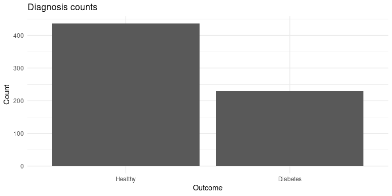

```r
data %>% ggplot(mapping = aes(x=as.factor(Outcome))) +
  geom_bar() +
  theme_minimal() +
  labs(
    x = "Outcome",
    y = "Count",
    title = "Diagnosis counts"
  )
```

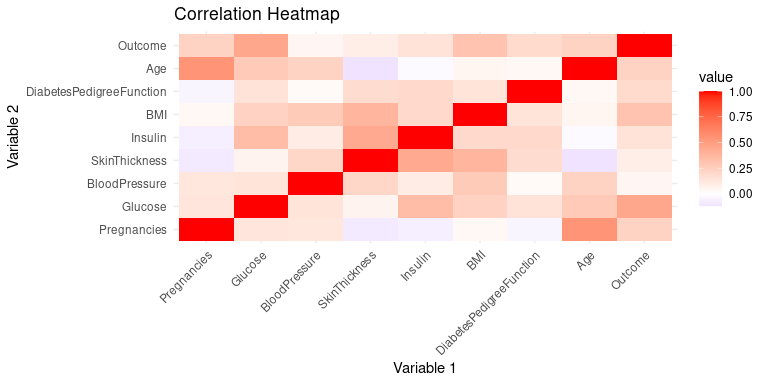

```r
cor_data <- cor(read.csv("PimaIndiansDiabetes.csv"))
melt_cor_data <- melt(cor_data)
ggplot(data = melt_cor_data, aes(x=Var1, y=Var2, fill=value)) +
  geom_tile() +
  scale_fill_gradient2(low = "blue", high = "red", mid = "white", midpoint = 0) +
  theme_minimal() +
  theme(axis.text.x = element_text(angle = 45, vjust = 1, hjust = 1)) +
  labs(
    x= "Variable 1",
    y= "Variable 2",
    title = "Correlation Heatmap"
  )
```

The violin plots shows us the distribution of our populations for each value, and gives a hint at present outliers. We see that some of them also contain missing data (to be handled later). The jittered point plot reveals some clear clusters being observable between the diagnosis. The most notable one is in the **Glucose** & **BMI** plot, which is also confirmed by the correlation heat map - these should be the most contributing variables to the predictions.

# Q3 + Q4: Handling missing data & Normalization

## Identifying missing values

Let’s have a glance which IVs contain 0s indicating missing variables and whether they are actual NAs or they make biological sense

```r
# We know that there are some missing values coded as 0, let's check which columns contain such missing data
for (i in 1:8){
  paste0(c(colnames(data)[i], ": ", (data %>% filter(data[,i] == 0) %>% nrow())), collapse = "") %>% print()
}
```

```
[1] "Pregnancies: 102"
[1] "Glucose: 5"
[1] "BloodPressure: 32"
[1] "SkinThickness: 196"
[1] "Insulin: 322"
[1] "BMI: 9"
[1] "DiabetesPedigreeFunction: 0"
[1] "Age: 0"
```

```r
# It is expected to find 0s for pregnancies, however, it doesn't make biological sense to have 0s in the remaining categories.
# Let's convert them to NAs so we can use KNN Imputer
data_na <- read.csv("PimaIndiansDiabetes.csv") %>%  mutate_at(2:6 ,~na_if(., 0))
```

We see that **Age** and **DiabetesPedigreeFunction** have no entries where the value is 0. We have quite a lot of 0s for pregnancies, but that makes buological sense. For the remaining variables: **Glucose**, **BloodPressure**, **SkinThickness**, **Insulin**, **BMI**, we will assume that the 0s represent NAs and hence should be imputed. We can’t realy drop the NAs as **Insulin** has 322 missing values and we would loose a lot of our data.

## Normalization

In order to handle the missing data, I want to deploy an KNN imputer. This however requires the dataset to be normalized a slightly earlier than the homework asks for. However, any imputed data should be within the normalized range.

```r
# Q4! Since I plan to use KNN Imputer I want to normalize the dataset first as KNN performs better with normalized data.
for (i in 1:8){
  tmp_mean <- mean(data_na[,i], na.rm = T)
  tmp_sd <- sd(data_na[,i], na.rm = T)
  data_na[,i] <- (data_na[,i] - tmp_mean)/tmp_sd
}
```

## Imputing

Originally I planned to remove the DV from the data available for the KNN Imputer, but based on https://doi.org/10.1186/s12874-016-0281-5 I learned that it is better to keep the DV for the imputer.

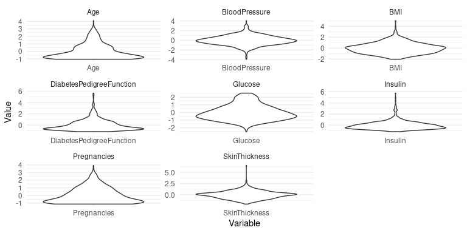

```r
# Q3 Ctd

# Run the KNN Imputer and bring back the outcome column
data_na <- impute.knn(as.matrix(data_na), k = 51, rowmax = 0.5, colmax = 0.8, maxp = 1500, rng.seed=362436069)
imputed_data <- data_na[["data"]] %>% as.data.frame()
imputed_data$Outcome <- read.csv("PimaIndiansDiabetes.csv")$Outcome

# Now let's re-inspect the data

data_long_imp <- imputed_data  %>% pivot_longer(cols = 1:8, names_to = "Variable", values_to = "Value")

data_long_imp %>% ggplot(mapping = aes(x=Variable, y=Value)) +
  geom_violin() +
  facet_wrap(vars(Variable), scales = "free") +
  theme_minimal()
```

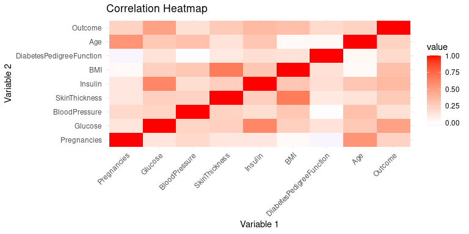

```r
cor_data_imp <- cor(imputed_data)
melt_cor_data_imp <- melt(cor_data_imp)
ggplot(data = melt_cor_data_imp, aes(x=Var1, y=Var2, fill=value)) +
  geom_tile() +
  scale_fill_gradient2(low = "blue", high = "red", mid = "white", midpoint = 0) +
  theme_minimal() +
  theme(axis.text.x = element_text(angle = 45, vjust = 1, hjust = 1)) +
  labs(
    x= "Variable 1",
    y= "Variable 2",
    title = "Correlation Heatmap"
  )
```

```r
# Refactorize the outcome
imputed_data$Outcome <- imputed_data$Outcome %>% factor()
```

Looking at our violin plots their general “shapes” have remained almost the same, with the “tails” caused by excess NAs in the form have been de-facto trimmed. This means that our imputer maintained the relative distribution of our values. We can also observe change in the correlation heat map, boosting the importance of some factors that were otherwise masked by the high number of 0 present.

# Q5 : Model Training

For this dataset I plan to try to train 3 types of models:

1. KNN
2. Random Forest
3. Neural network

The best performer will be then chosen based on the the mixture of highest and least variable AUC across parameters.

## K-Fold Validation & AUC

In order to utilize 100% of our dataset let’s perform the k-fold validation. We can use **vfold_cv** command from base R. The performance of the model will be assessed using AUC.

```r
# Split our dataset into 10 folds for validation
fold_data <- vfold_cv(imputed_data)
# Set the evaluation approach: Area Under Curve (AUC)
roc_res <- metric_set(roc_auc)
```

## Random Forest

Let’s use grid search to hyper tune the random forest. Engine used for the forest will be cforest from party package. The parameters used for hyper tuning will be

1. number of random variables (mtry)
2. number of trees

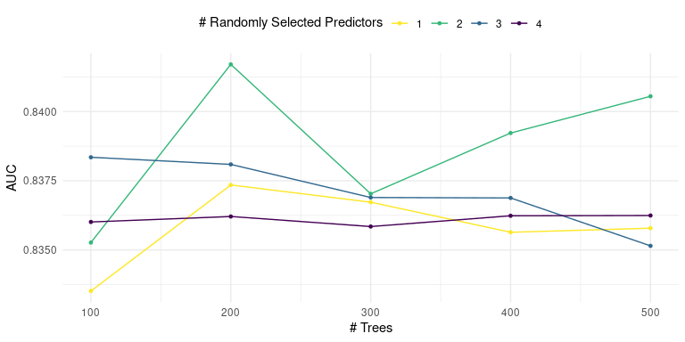

```r
# Let's create a Tidy Random Forest Model
# The tidy approach allows us to modify the engine in the
# later stage of the project
rf_model = rand_forest(mtry=tune(), trees = tune()) %>%
  set_engine("partykit", trace = 0) %>%
  set_mode("classification")

# Extract parameters to tune
rf_param <- extract_parameter_set_dials(rf_model)

# Create parameter grid
rf_grid <- crossing(
  mtry = 1:4,
  trees = c(100, 200, 300, 400, 500))

# Set the model's recipe
rf_rec <- recipe(Outcome ~ ., data = imputed_data)

# Combine the model and recipe
rf_wflow <-
  workflow() %>%
  add_model(rf_model) %>%
  add_recipe(rf_rec)

# Edit the parameters to it knows what to expect
rf_param <-
  rf_wflow %>%
  extract_parameter_set_dials() %>%
  update(
    mtry = mtry(range(1,4)),
    trees = trees(c(100,500))
  )

# Perform Grid Search
rf_reg_tune <-
  rf_wflow %>%
  tune_grid(
    fold_data,
    grid = rf_grid,
    metrics = roc_res
  )

# Results
autoplot(rf_reg_tune) +
  theme_minimal() +
  scale_color_viridis_d(direction = -1) +
  theme(legend.position = "top") +
  labs(y= "AUC")
```

## KNN

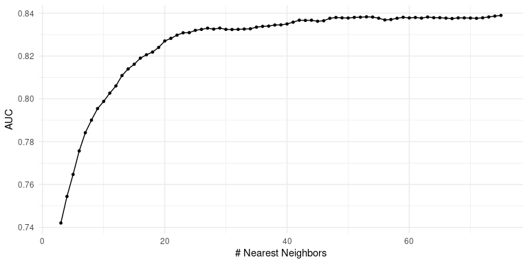

```r
# Tidy (Parsnip's) KNN Model
knn_model = nearest_neighbor(neighbors=tune()) %>%
  set_engine("kknn", trace = 0) %>%
  set_mode("classification")

# Extract parameters to tune
knn_param <- extract_parameter_set_dials(knn_model)

# Create parameter grid
knn_grid <- crossing(
  neighbors = 3:75)

# Set the model's recipe
knn_rec <- recipe(Outcome ~ ., data = imputed_data)

# Combine the model and recipe
knn_wflow <-
  workflow() %>%
  add_model(knn_model) %>%
  add_recipe(knn_rec)

# Edit the parameters to it knows what to expect
knn_param <-
  knn_wflow %>%
  extract_parameter_set_dials() %>%
  update(
    neighbors = neighbors(range(3,75))
  )

# Perform Grid Search
knn_reg_tune <-
  knn_wflow %>%
  tune_grid(
    fold_data,
    grid = knn_grid,
    metrics = roc_res
  )

# Results
autoplot(knn_reg_tune) +
  scale_color_viridis_d(direction = -1) +
  theme(legend.position = "top") +
  theme_minimal() +
  labs(y= "AUC")
```

The KNN’s hypertuning through grid search revealed that the performance platens at k=50, however most of the importance is achieved at k=29

## Neural Networks

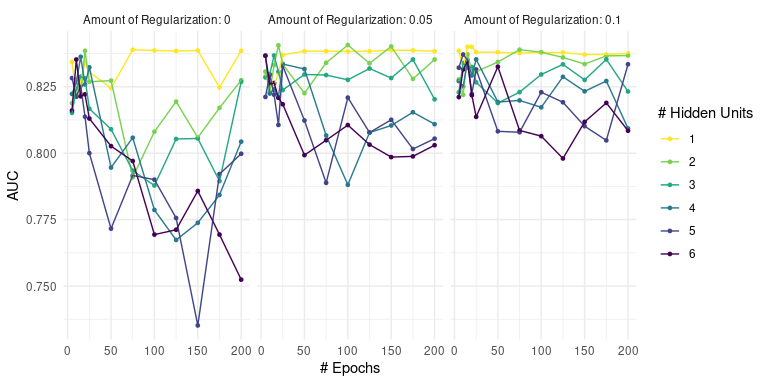

```r
# Tidy (Parsnip's) Neural Network Model
nn_model = mlp(hidden_units = tune(), penalty = tune(), epochs = tune()) %>%
  set_engine("nnet", trace = 0) %>%
  set_mode("classification")

# Create parameter grid
nn_grid <- crossing(
  hidden_units = 1:6,
  penalty = c(0.0, 0.05, 0.1),
  epochs = c(5,10,15,20,25,50,75,100,125,150,175,200))

# Set the model's recipe
nn_rec <- recipe(Outcome ~ ., data = imputed_data)

# Combine the model and recipe
nn_wflow <-
  workflow() %>%
  add_model(nn_model) %>%
  add_recipe(nn_rec)

# Edit the parameters so it knows what to expect
nn_param <-
  nn_wflow %>%
  extract_parameter_set_dials() %>%
  update(
    hidden_units = hidden_units(range(1:6)),
    penalty = penalty(range(0.0:0.1)),
    epochs = epochs(range(10:200)))

# Perform Grid Search
nn_reg_tune <-
  nn_wflow %>%
  tune_grid(
    fold_data,
    grid = nn_grid,
    metrics = roc_res
  )

# Results
autoplot(nn_reg_tune) +
  scale_color_viridis_d(direction = -1) +
  theme(legend.position = "top") +
  theme_minimal() +
  labs(y= "AUC")
```

Hypertuning of the neural network shows that the model with 1 hidden unit had the most consistent performance. Although some other models peaked above that one, it has been less consistent overall.

# Q6: Wrapping up

Both the neural network and random forest managed to produce at least one model that produced consistent AUC, and the KNN also seems quite promising. KNN as a model requires to store the dataset and doesn’t handle outliers very well. Additionally both random forest and neural networks are somewhat prone to noise in randomness due to the seed. I’ve noticed that across multiple renderings and running of the code the best parameters and AUC fluctuated. As such the random forest seems to more consistent (smaller variation in the AUC), and thus I am going to go to choose random forest model due to its consistency. The chosen parameters are the one that came out the highest at the time of writing.

## Final Model

Let’s build the final model and save it as an R object. The acutal apramters here might differ from the best metrics above as there are mild fluctiations due to the seed used.

```r
final_model <- cforest(Outcome ~ ., imputed_data, ntree = 500, mtry = 2)
saveRDS(final_model, "jj3003_cforest.rds")
```